# Social Control - SensitivitySocialProcesses

Pascal Küng, MSc, Patrick Höhener, MSc, James M. Allen, PhD, Robert Tobias, PhD, Urte Scholz, PhD

2025-08-14

```r
knitr::opts_chunk$set(echo = TRUE)

rm(list = ls())

#cmdstanr::set_cmdstan_path(path = "C:/Users/kueng/.cmdstan/cmdstan-2.35.0")
#cmdstanr::set_cmdstan_path(path = "C:/Users/pascku/.cmdstan/cmdstan-2.36.0")

library(tidyverse)
library(R.utils)
library(wbCorr)
library(readxl)
library(kableExtra)
library(brms)
library(bayesplot)
library(see)
library(beepr)
library(DHARMa)
library(digest)




source(file.path('Functions', 'ReportModels.R'))
source(file.path('Functions', 'PrettyTables.R'))
source(file.path('Functions', 'ReportMeasures.R'))
source(file.path('Functions', 'PrepareData.R'))

report_function_hash <- digest::digest(summarize_brms)
```

```r
system("shutdown /a")
```

```
## [1] 1116
```

```r
# Set options for analysis
use_mi = FALSE
shutdown = FALSE
report_ordinal = FALSE
do_priorsense = FALSE
get_bayesfactor = FALSE
check_models = FALSE #

if (get_bayesfactor) {
  stats_to_report <- c('CI', 'SE', 'pd', 'ROPE', 'BF', 'Rhat', 'ESS')
} else {
  stats_to_report <- c('CI', 'SE', 'pd', 'ROPE', 'Rhat', 'ESS')
}

options(
  dplyr.print_max = 100,
  brms.backend = 'cmdstan',
  brms.file_refit = ifelse(use_mi, 'never', 'on_change'),
  brms.file_refit = 'on_change',
  #brms.file_refit = 'always',
  error = function() {
    beepr::beep(sound = 5)
    if (shutdown) {
      system("shutdown /s /t 180")
      quit(save = "no", status = 1)
    }
  }
  , es.use_symbols = TRUE
)


####################### Model parameters #######################

iterations = 12000 # 12'000 per chain to achieve 40'000
warmup = 2000 # 2000

# NO AR!!!
#corstr = 'ar'
#corstr = 'cosy_couple'
#corstr = 'cosy_couple:user'


################################################################

suffix = paste0('_SensitivityExchangeProcesses_', as.character(iterations))
```

```r
df <- openxlsx::read.xlsx(file.path('long.xlsx'))
df_original <- df

df_double <- prepare_data(df, recode_pushing = TRUE, use_mi = use_mi)[[1]]
```

Constructing scales Re-coding pusing reshaping data (4field) centering data within and between

```r
summary(df_double$pushing)
```

Min. 1st Qu. Median Mean 3rd Qu. Max. NA’s 0.0000 0.0000 0.0000 0.1649 0.0000 5.0000 275

# Modelling

```r
# For indistinguishable Dyads
model_rows_fixed <- c(
    'Intercept',
    # '-- WITHIN PERSON MAIN EFFECTS --',
    'persuasion_self_cw',
    'persuasion_partner_cw',
    'pressure_self_cw',
    'pressure_partner_cw',
    'pushing_self_cw',
    'pushing_partner_cw',
    'day',
    'plan_selfPlan',
    'plan_partnerPlan',

    'support_self_cw',
    'support_partner_cw',
    'isWeekendWeekend',
    'got_JITAI_selfJITAIreceived',
    'skilled_supportDaysafterIntervention',

    'weartime_self_cw',


    # '-- BETWEEN PERSON MAIN EFFECTS',
    'persuasion_self_cb',
    'persuasion_partner_cb',
    'pressure_self_cb',
    'pressure_partner_cb',
    'pushing_self_cb',
    'pushing_partner_cb',

    'support_self_cb',
    'support_partner_cb',
    'studyGroupFirst3weeksinterventions',
    'studyGrouplast3weeksinterventions',

    'weartime_self_cb'
  )


model_rows_fixed_ordinal <- c(
  model_rows_fixed[1],
  'Intercept[1]',
  'Intercept[2]',
  'Intercept[3]',
  'Intercept[4]',
  'Intercept[5]',
  model_rows_fixed[2:length(model_rows_fixed)]
)

model_rows_random <- c(
  # '--------------',
  # '-- RANDOM EFFECTS --',
  'coupleID: sd(Intercept)',

  'coupleID:userID: sd(Intercept)',
  'coupleID:userID: sd(persuasion_self_cw)',
  'coupleID:userID: sd(persuasion_partner_cw)',
  'coupleID:userID: sd(pressure_self_cw)',
  'coupleID:userID: sd(pressure_partner_cw)',
  'coupleID:userID: sd(pushing_self_cw)',
  'coupleID:userID: sd(pushing_partner_cw)',

  # '-- CORRELATION STRUCTURE -- ',
  'sigma'
)

model_rows_random_ordinal <- c(model_rows_random,'disc')
```

```r
# For indistinguishable Dyads
model_rownames_fixed <- c(
    "Intercept",
    # "-- WITHIN PERSON MAIN EFFECTS --",
    "Daily individual's experienced persuasion",
    "Daily partner's experienced persuasion",
    "Daily individual's experienced pressure",
    "Daily partner's experienced pressure",
    "Daily individual's experienced pushing",
    "Daily partner's experienced pushing",
    "Day",
    "Own action plan",
    'Partner action plan',

    'Daily support received',
    "Daily support provided (partner's view)",
    'Is a Weekend',
    'JITAI received',
    'Days post skilled support intervention',

    "Daily wear time",

    # "-- BETWEEN PERSON MAIN EFFECTS",
    "Mean individual's experienced persuasion",
    "Mean partner's experienced persuasion",
    "Mean individual's experienced pressure",
    "Mean partner's experienced pressure",
    "Mean individual's experienced pushing",
    "Mean partner's experienced pushing",

    "Mean individual's received support",
    "Mean partner's received support",
    'Difference study group 2',
    'Difference study group 3',

    "Mean wear time"
  )


model_rownames_fixed_ordinal <- c(
  model_rownames_fixed[1],
  'Intercept[1]',
  'Intercept[2]',
  'Intercept[3]',
  'Intercept[4]',
  'Intercept[5]',
  model_rownames_fixed[2:length(model_rownames_fixed)]
)


model_rownames_random <- c(
  # '--------------',
  # '-- RANDOM EFFECTS L3 --',
  'L3:sd(Intercept)',


  'L2:sd(Intercept)',
  "L2:sd(Daily individual's experienced persuasion)",
  "L2:sd(Daily partner's experienced persuasion)", # OR partner received
  "L2:sd(Daily individual's experienced pressure)",
  "L2:sd(Daily partner's experienced pressure)",
  "L2:sd(Daily individual's experienced pushing)",
  "L2:sd(Daily partner's experienced pushing)",

  # '-- CORRELATION STRUCTURE L1 -- ',
  'sigma'
)

model_rownames_random_ordinal <- c(model_rownames_random,'disc')
```

```r
rows_to_pack <- list(
  "Within-Person Effects" = c(2,16),
  "Between-Person Effects" = c(17,27),
  "Random Effects (Level 3 - Couple)" = c(28, 28),
  "Random Effects (Level 2 - Couple:Person)" = c(29, 35),
  "Additional Parameters" = c(36,36)
  )


rows_to_pack_ordinal <- list(
  "Intercepts" = c(1,6),
  "Within-Person Effects" = c(2+5,16+5),
  "Between-Person Effects" = c(17+5,27+5),
  "Random Effects (Level 3 - Couple)" = c(28+5, 28+5),
  "Random Effects (Level 2 - Couple:Person)" = c(29+5, 35+5),
  "Additional Parameters" = c(36+5,36+6)
  )
```

rows_to_pack <- list( “Within-Person Effects” = c(2,11), “Between-Person Effects” = c(12,18), “Random Effects (Level 3 - Couple)” = c(19, 25), “Random Effects (Level 2 - Couple:Person)” = c(26, 26), “Additional Parameters” = c(27,27) )

rows_to_pack_ordinal <- list( “Within-Person Effects” = c(2+5,11+5), “Between-Person Effects” = c(12+5,18+5), “Random Effects (Level 3 - Couple)” = c(19+5, 25+5), “Random Effects (Level 2 - Couple:Person)” = c(26+5, 26+5), “Additional Parameters” = c(27+5,27+6) )

## Self-Reported MVPA

### Hurdle Lognormal Model

```r
formula <- bf(
  pa_sub ~
    persuasion_self_cw + persuasion_partner_cw +
    pressure_self_cw + pressure_partner_cw +
    pushing_self_cw + pushing_partner_cw +

    support_self_cw + support_partner_cw +
    #isWeekend +
    #got_JITAI_self +
    #skilled_support +

    persuasion_self_cb + persuasion_partner_cb +
    pressure_self_cb + pressure_partner_cb +
    pushing_self_cb + pushing_partner_cb +

    support_self_cb + support_partner_cb +
    #studyGroup +

    plan_self + plan_partner +
    day +

    # Random effects
    (1 | dd | coupleID)

  + (1 + persuasion_self_cw + persuasion_partner_cw +
    pressure_self_cw + pressure_partner_cw +
    pushing_self_cw + pushing_partner_cw | d_u | coupleID:userID),

  hu = ~ persuasion_self_cw + persuasion_partner_cw +
    pressure_self_cw + pressure_partner_cw +
    pushing_self_cw + pushing_partner_cw +

    support_self_cw + support_partner_cw +
    #isWeekend +
    #got_JITAI_self +
    #skilled_support +

    persuasion_self_cb + persuasion_partner_cb +
    pressure_self_cb + pressure_partner_cb +
    pushing_self_cb + pushing_partner_cb +

    support_self_cb + support_partner_cb +
    #studyGroup +

    plan_self + plan_partner +
    day +

    # Random effects
    (1 | dd | coupleID)

  + (1 + persuasion_self_cw + persuasion_partner_cw +
    pressure_self_cw + pressure_partner_cw +
    pushing_self_cw + pushing_partner_cw | d_u | coupleID:userID)

  , decomp = 'QR'
  #, autocor = autocor_str
)

prior1 <- c(
  brms::set_prior("normal(0, 2.5)", class = "b")
  , brms::set_prior("normal(0, 2)", class = "b", dpar = "hu")
  , brms::set_prior("normal(0, 50)", class = "Intercept") # for non-zero PA
  , brms::set_prior("normal(0.5, 2.5)", class = "Intercept", dpar = 'hu') # hurdle part
  , brms::set_prior("normal(0, 2)", class = "sd", group = "coupleID", lb = 0)
  , brms::set_prior("student_t(3, 0, 2.5)", class = "sigma", lb = 0)
)

#brms::validate_prior(
#  prior1,
#  formula = formula,
#  data = df_double,
#  family = hurdle_lognormal()
#)

#df_minimal <- df_double[, c("AorB", all.vars(as.formula(formula)))]

pa_sub <- my_brm(
  mi = use_mi,
  imputed_data = implist,

  formula = formula,
  prior = prior1,
  data = df_double,
  family = brms::hurdle_lognormal(),
  #family = brms::hurdle_negbinomial(),
  #family = brms::hurdle_poisson(),
  #control = list(adapt_delta = 0.95, max_treedepth = 15),
  iter = iterations,
  warmup = warmup,
  chains = 4,
  cores = 4,
  seed = 42,
  file = file.path("models_cache_brms", paste0("pa_sub_hu_lognormal", suffix))
  #, file_refit = 'always'
)
pa_sub_digest <- digest::digest(pa_sub)
```

```r
# rope range for continuous part of the model
rope_factor <- sd(log(pa_sub$data$pa_sub[pa_sub$data$pa_sub > 0]))
rope_range_continuous = c(-0.1 * rope_factor, 0.1 * rope_factor)

summary_pa_sub <- summarize_brms(
  pa_sub,
  stats_to_report = stats_to_report,
  rope_range = rope_range_continuous,
  hu_rope_range = c(-0.18, 0.18),
  model_rows_fixed = model_rows_fixed,
  model_rows_random = model_rows_random,
  model_rownames_fixed = model_rownames_fixed,
  model_rownames_random = model_rownames_random,
  exponentiate = T)
# Print the updated dataframe
summary_pa_sub %>%
  print_df(rows_to_pack = rows_to_pack)
```

|  | exp(Est.)_hu | SE_hu | 95% CI_hu | pd_hu | ROPE_hu | inside ROPE_hu | Rhat_hu | Bulk_ESS_hu | Tail_ESS_hu | exp(Est.)_nonzero | SE_nonzero | 95% CI_nonzero | pd_nonzero | ROPE_nonzero | inside ROPE_nonzero | Rhat_nonzero | Bulk_ESS_nonzero | Tail_ESS_nonzero |
| --- | --- | --- | --- | --- | --- | --- | --- | --- | --- | --- | --- | --- | --- | --- | --- | --- | --- | --- |
| Intercept | 0.22*** | 0.04 | [ 0.15, 0.32] | 1.000 | [0.84, 1.20] | 0.000 | 1.000 | 39315 | 34593 | 34.07*** | 3.05 | [28.53, 40.78] | 1.000 | [0.92, 1.08] | 0.000 | 1.000 | 19761 | 23700 |
| **Within-Person Effects** |  |  |  |  |  |  |  |  |  |  |  |  |  |  |  |  |  |  |
| Daily individual’s experienced persuasion | 1.23** | 0.10 | [ 1.06, 1.47] | 0.996 | [0.84, 1.20] | 0.365 | 1.000 | 47997 | 33325 | 1.00 | 0.02 | [ 0.95, 1.04] | 0.552 | [0.92, 1.08] | 0.999 | 1.000 | 43782 | 35142 |
| Daily partner’s experienced persuasion | 1.09 | 0.08 | [ 0.94, 1.28] | 0.880 | [0.84, 1.20] | 0.872 | 1.000 | 52752 | 32290 | 1.00 | 0.02 | [ 0.96, 1.04] | 0.515 | [0.92, 1.08] | 1.000 | 1.000 | 56875 | 35077 |
| Daily individual’s experienced pressure | 0.98 | 0.21 | [ 0.63, 1.68] | 0.541 | [0.84, 1.20] | 0.583 | 1.000 | 34781 | 28327 | 0.91 | 0.05 | [ 0.82, 1.00] | 0.972 | [0.92, 1.08] | 0.372 | 1.000 | 43357 | 38667 |
| Daily partner’s experienced pressure | 1.98** | 0.63 | [ 1.19, 4.86] | 0.997 | [0.84, 1.20] | 0.025 | 1.000 | 23272 | 25091 | 0.95 | 0.04 | [ 0.87, 1.04] | 0.864 | [0.92, 1.08] | 0.764 | 1.000 | 44393 | 38941 |
| Daily individual’s experienced pushing | 0.92 | 0.14 | [ 0.69, 1.30] | 0.705 | [0.84, 1.20] | 0.688 | 1.000 | 44246 | 29561 | 0.97 | 0.03 | [ 0.91, 1.03] | 0.843 | [0.92, 1.08] | 0.947 | 1.000 | 57261 | 34321 |
| Daily partner’s experienced pushing | 1.19 | 0.15 | [ 0.94, 1.57] | 0.929 | [0.84, 1.20] | 0.508 | 1.000 | 55809 | 30352 | 0.96 | 0.03 | [ 0.91, 1.01] | 0.931 | [0.92, 1.08] | 0.918 | 1.000 | 66324 | 34301 |
| Day | 0.84 | 0.14 | [ 0.61, 1.16] | 0.854 | [0.84, 1.20] | 0.506 | 1.000 | 93170 | 29505 | 0.97 | 0.06 | [ 0.86, 1.09] | 0.693 | [0.92, 1.08] | 0.756 | 1.000 | 84475 | 30877 |
| Own action plan | 11.23*** | 1.28 | [ 9.00, 14.09] | 1.000 | [0.84, 1.20] | 0.000 | 1.000 | 66287 | 31205 | 1.37*** | 0.07 | [ 1.25, 1.51] | 1.000 | [0.92, 1.08] | 0.000 | 1.000 | 84626 | 32212 |
| Partner action plan | 1.05 | 0.12 | [ 0.85, 1.31] | 0.682 | [0.84, 1.20] | 0.856 | 1.000 | 79718 | 33555 | 1.03 | 0.05 | [ 0.95, 1.12] | 0.769 | [0.92, 1.08] | 0.851 | 1.000 | 89051 | 30358 |
| Daily support received | 1.73*** | 0.09 | [ 1.57, 1.91] | 1.000 | [0.84, 1.20] | 0.000 | 1.000 | 83289 | 31312 | 1.07*** | 0.01 | [ 1.05, 1.10] | 1.000 | [0.92, 1.08] | 0.699 | 1.000 | 89537 | 30695 |
| Daily support provided (partner’s view) | 1.41*** | 0.06 | [ 1.28, 1.54] | 1.000 | [0.84, 1.20] | 0.000 | 1.000 | 84243 | 29864 | 1.05*** | 0.01 | [ 1.02, 1.07] | 1.000 | [0.92, 1.08] | 0.992 | 1.001 | 94352 | 31097 |
| Is a Weekend | NA | NA | NA | NA | NA | NA | NA | NA | NA | NA | NA | NA | NA | NA | NA | NA | NA | NA |
| JITAI received | NA | NA | NA | NA | NA | NA | NA | NA | NA | NA | NA | NA | NA | NA | NA | NA | NA | NA |
| Days post skilled support intervention | NA | NA | NA | NA | NA | NA | NA | NA | NA | NA | NA | NA | NA | NA | NA | NA | NA | NA |
| Daily wear time | NA | NA | NA | NA | NA | NA | NA | NA | NA | NA | NA | NA | NA | NA | NA | NA | NA | NA |
| **Between-Person Effects** |  |  |  |  |  |  |  |  |  |  |  |  |  |  |  |  |  |  |
| Mean individual’s experienced persuasion | 1.38 | 0.64 | [ 0.54, 3.44] | 0.756 | [0.84, 1.20] | 0.239 | 1.000 | 30197 | 29408 | 0.95 | 0.19 | [ 0.63, 1.42] | 0.598 | [0.92, 1.08] | 0.294 | 1.000 | 40267 | 32658 |
| Mean partner’s experienced persuasion | 1.12 | 0.52 | [ 0.43, 2.78] | 0.593 | [0.84, 1.20] | 0.295 | 1.000 | 29545 | 29044 | 0.87 | 0.18 | [ 0.58, 1.31] | 0.748 | [0.92, 1.08] | 0.243 | 1.000 | 36966 | 31356 |
| Mean individual’s experienced pressure | 0.12** | 0.09 | [ 0.03, 0.46] | 0.999 | [0.84, 1.20] | 0.002 | 1.000 | 40178 | 33480 | 0.80 | 0.36 | [ 0.32, 2.01] | 0.692 | [0.92, 1.08] | 0.120 | 1.001 | 12679 | 21211 |
| Mean partner’s experienced pressure | 0.25* | 0.18 | [ 0.06, 0.98] | 0.977 | [0.84, 1.20] | 0.029 | 1.000 | 40466 | 33627 | 0.54 | 0.25 | [ 0.21, 1.37] | 0.906 | [0.92, 1.08] | 0.055 | 1.001 | 12358 | 19132 |
| Mean individual’s experienced pushing | 0.78 | 0.57 | [ 0.18, 3.34] | 0.635 | [0.84, 1.20] | 0.186 | 1.000 | 35884 | 31368 | 1.35 | 0.48 | [ 0.66, 2.75] | 0.797 | [0.92, 1.08] | 0.123 | 1.000 | 22853 | 28148 |
| Mean partner’s experienced pushing | 1.60 | 1.18 | [ 0.37, 6.87] | 0.737 | [0.84, 1.20] | 0.160 | 1.000 | 35379 | 31721 | 1.54 | 0.56 | [ 0.75, 3.18] | 0.878 | [0.92, 1.08] | 0.087 | 1.000 | 20337 | 27005 |
| Mean individual’s received support | 1.26 | 0.21 | [ 0.91, 1.76] | 0.919 | [0.84, 1.20] | 0.368 | 1.000 | 38262 | 32106 | 1.11 | 0.08 | [ 0.96, 1.28] | 0.929 | [0.92, 1.08] | 0.352 | 1.000 | 39828 | 32562 |
| Mean partner’s received support | 1.53** | 0.25 | [ 1.11, 2.13] | 0.995 | [0.84, 1.20] | 0.067 | 1.000 | 40552 | 32482 | 0.97 | 0.07 | [ 0.85, 1.12] | 0.655 | [0.92, 1.08] | 0.704 | 1.000 | 36009 | 32419 |
| Difference study group 2 | NA | NA | NA | NA | NA | NA | NA | NA | NA | NA | NA | NA | NA | NA | NA | NA | NA | NA |
| Difference study group 3 | NA | NA | NA | NA | NA | NA | NA | NA | NA | NA | NA | NA | NA | NA | NA | NA | NA | NA |
| Mean wear time | NA | NA | NA | NA | NA | NA | NA | NA | NA | NA | NA | NA | NA | NA | NA | NA | NA | NA |
| **Random Effects (Level 3 - Couple)** |  |  |  |  |  |  |  |  |  |  |  |  |  |  |  |  |  |  |
| L3:sd(Intercept) | 0.80 | 0.13 | [0.57, 1.12] | NA | NA | NA | 1.000 | 22524 | 26132 | 0.29 | 0.07 | [0.14, 0.43] | NA | NA | NA | 1.001 | 7181 | 6527 |
| **Random Effects (Level 2 - Couple:Person)** |  |  |  |  |  |  |  |  |  |  |  |  |  |  |  |  |  |  |
| L2:sd(Intercept) | 0.42 | 0.10 | [0.23, 0.66] | NA | NA | NA | 1.000 | 16532 | 23608 | 0.24 | 0.04 | [0.16, 0.34] | NA | NA | NA | 1.000 | 8115 | 9735 |
| L2:sd(Daily individual’s experienced persuasion) | 0.31 | 0.12 | [0.06, 0.55] | NA | NA | NA | 1.000 | 13076 | 12579 | 0.12 | 0.02 | [0.08, 0.17] | NA | NA | NA | 1.000 | 27044 | 29326 |
| L2:sd(Daily partner’s experienced persuasion) | 0.31 | 0.12 | [0.06, 0.55] | NA | NA | NA | 1.000 | 11239 | 10417 | 0.07 | 0.02 | [0.02, 0.12] | NA | NA | NA | 1.000 | 14733 | 13104 |
| L2:sd(Daily individual’s experienced pressure) | 0.49 | 0.41 | [0.02, 1.59] | NA | NA | NA | 1.000 | 13362 | 22504 | 0.06 | 0.05 | [0.00, 0.20] | NA | NA | NA | 1.000 | 24073 | 25998 |
| L2:sd(Daily partner’s experienced pressure) | 0.67 | 0.51 | [0.04, 2.02] | NA | NA | NA | 1.000 | 11836 | 19932 | 0.05 | 0.04 | [0.00, 0.17] | NA | NA | NA | 1.000 | 24462 | 24268 |
| L2:sd(Daily individual’s experienced pushing) | 0.59 | 0.23 | [0.13, 1.12] | NA | NA | NA | 1.000 | 12782 | 11723 | 0.07 | 0.04 | [0.01, 0.15] | NA | NA | NA | 1.000 | 13424 | 17858 |
| L2:sd(Daily partner’s experienced pushing) | 0.22 | 0.19 | [0.01, 0.70] | NA | NA | NA | 1.000 | 15143 | 23477 | 0.05 | 0.04 | [0.00, 0.13] | NA | NA | NA | 1.000 | 16460 | 21934 |
| **Additional Parameters** |  |  |  |  |  |  |  |  |  |  |  |  |  |  |  |  |  |  |
| sigma | NA | NA | NA | NA | NA | NA | NA | NA | NA | 0.65 | 0.01 | [0.62, 0.67] | NA | NA | NA | 1.000 | 59277 | 29218 |

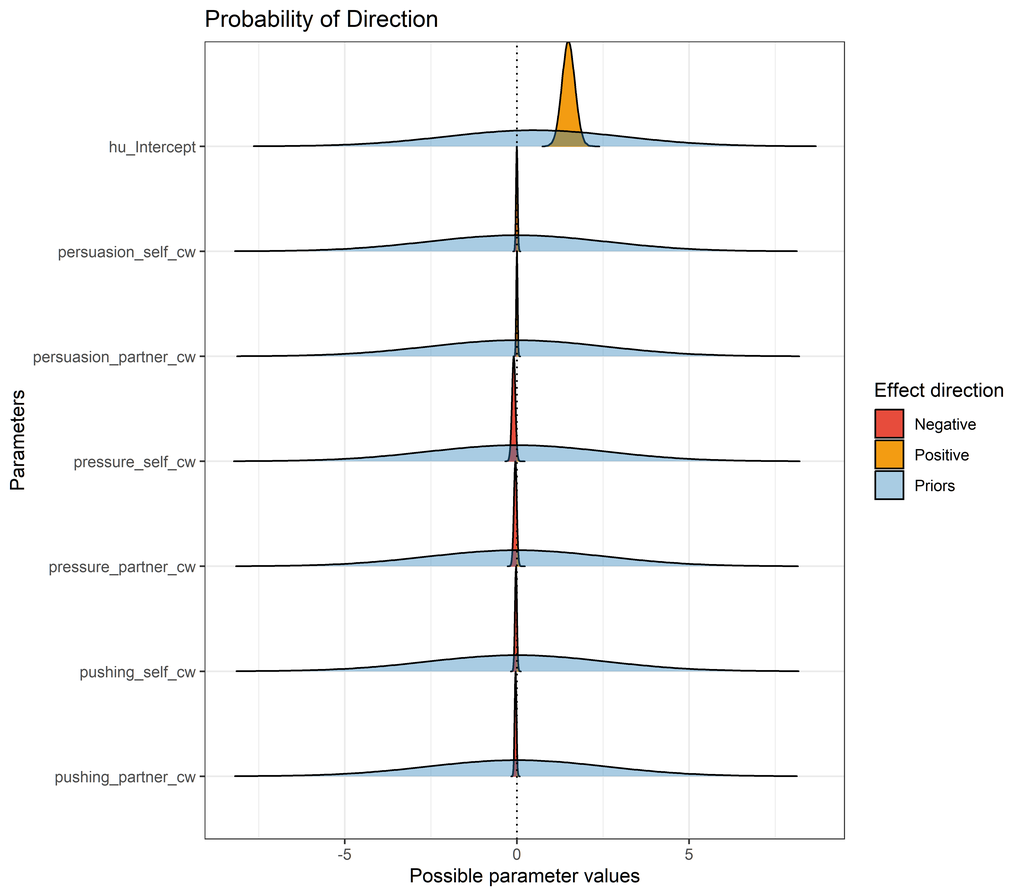

```r
# Plot continuous part of model

variable <- c(
  '(Intercept)',
  'b_persuasion_self_cw',
  'b_persuasion_partner_cw',
  'b_pressure_self_cw',
  'b_pressure_partner_cw',
  'b_pushing_self_cw',
  'b_pushing_partner_cw'
)


plot(
  bayestestR::p_direction(pa_sub, parameter = variable),
  priors = TRUE
) + theme_bw()
```

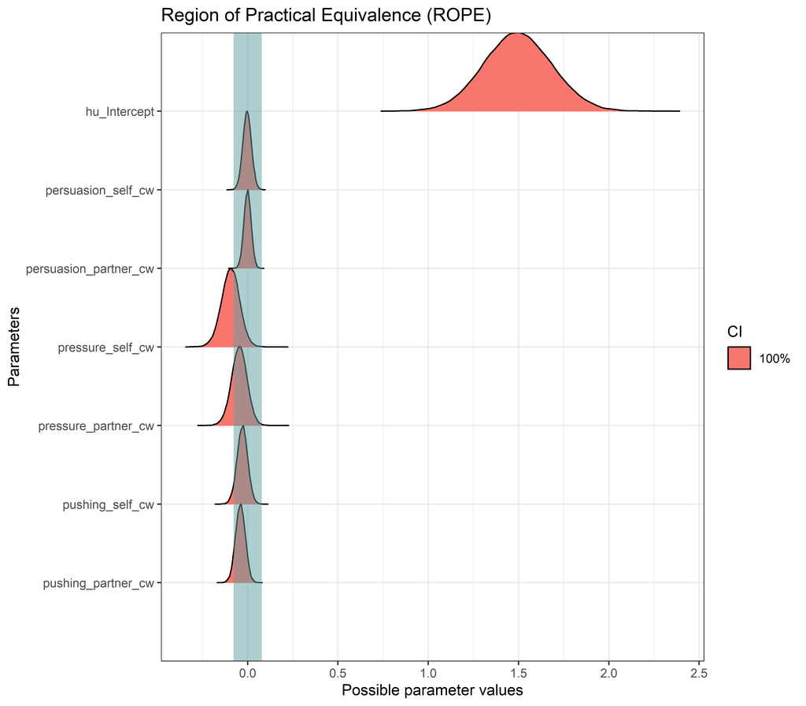

```r
plot(
  bayestestR::rope(
    pa_sub,
    parameter = variable,
    range = rope_range_continuous,
    verbose = F,
    ci = 1
  )
) + theme_bw()
```

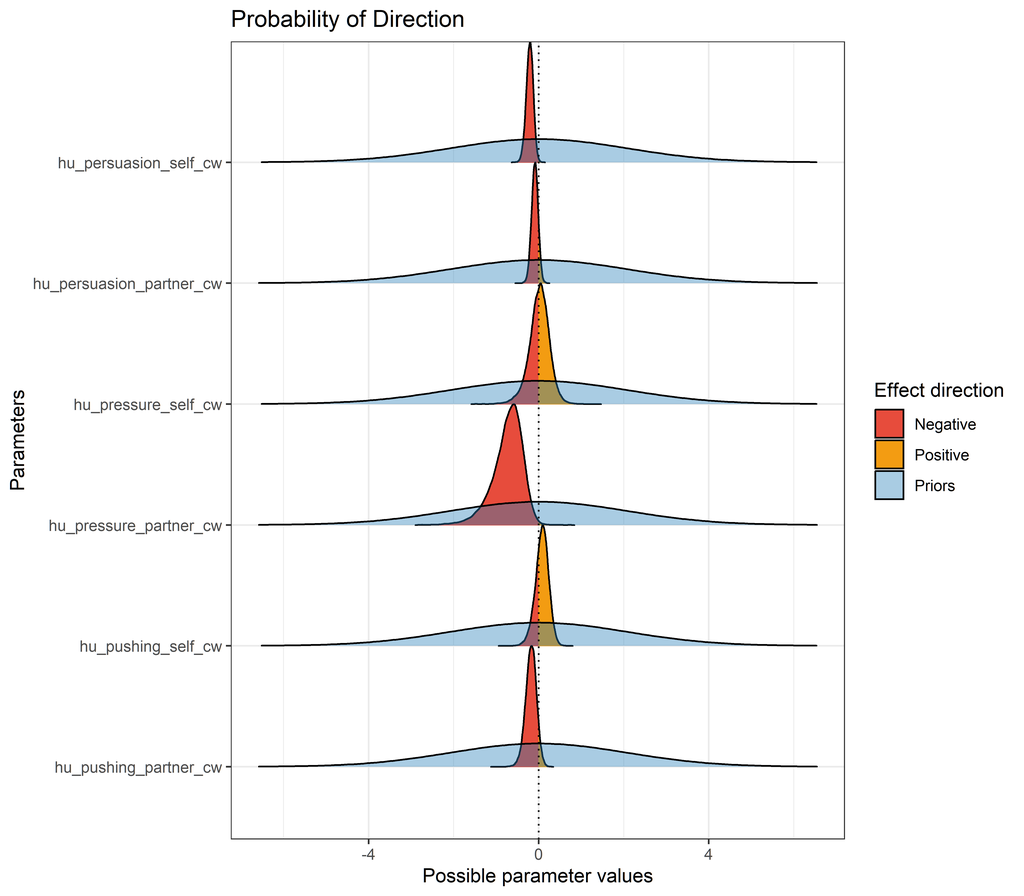

```r
# Hurdle part of the model
variable <- c(
  'b_hu_persuasion_self_cw',
  'b_hu_persuasion_partner_cw',
  'b_hu_pressure_self_cw',
  'b_hu_pressure_partner_cw',
  'b_hu_pushing_self_cw',
  'b_hu_pushing_partner_cw'
)

plot(
  bayestestR::p_direction(pa_sub, parameter = variable),
  priors = TRUE
) + theme_bw()
```

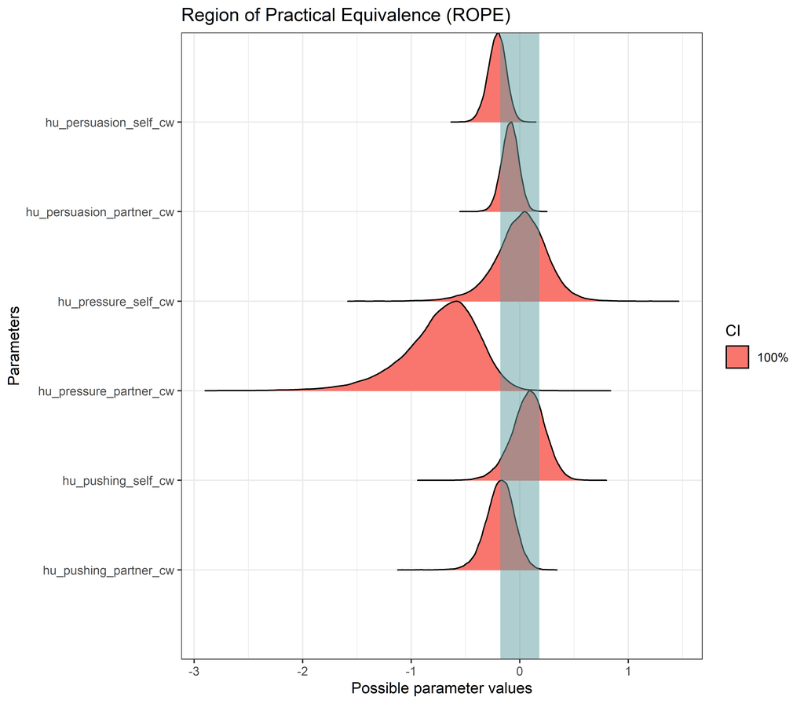

```r
# The rope range for the bernoulli part of the model is -0.18, 0.18
plot(
  bayestestR::rope(pa_sub, parameter = variable, range = c(-0.18, 0.18), ci = 1),
  verbose = FALSE
) + theme_bw()
```